# NRK-case

```r
library(data.table)
library(ggplot2)
## require(lubridate)
```

Leser inn datasettet.

```r
dt = fread("unge-lovende.csv")
```

## Utforskende dataanalyse

Starter med å bli litt kjent med dataene. Hvordan ser de seks første og seks siste radene ut?

```r
head(dt)
```

```
##                 userId    programId visitStartTime timeWithinVisit
## 1: 2172883450372358834 KMTE20000514     1447617021         1614261
## 2: 2214426530139075244 KMTE20000314     1447578419         1782834
## 3: 3261020776373483236 KMTE20000114     1447180923          206935
## 4: 3300130967635711526 KMTE20000114     1447139006         1630400
## 5: 3303148955234989541 KMTE20000614     1447186150         4274932
## 6: 3328043191237614106 KMTE20000114     1447152495         2439821
```

```r
tail(dt)
```

```
##                 userId    programId visitStartTime timeWithinVisit
## 1: 5896983029269891017 KMTE20000114     1447617759          714362
## 2: 5905516712715896759 KMTE20000214     1447613284         3577628
## 3: 5919706756387980942 KMTE20000314     1447605185         6229430
## 4: 2175042624863110707 KMTE20000114     1447767910         1626182
## 5: 2219498938030130414 KMTE20000514     1447724173         1461068
## 6: 2238231923224909338 KMTE20000414     1447715402          700797
```

Er det noen dupliserte rader?

```r
dt[duplicated(dt), .N]
```

```
## [1] 5
```

```r
dt = dt[!duplicated(dt)]
```

Det var noen, så jeg fjernet dem.

Undersøker dimensjonene til dt

```r
dim(dt)
```

```
## [1] 589769      4
```

Nesten 590 000 rader.

Sjekker hvor mange unike brukere det er

```r
dt[, uniqueN(userId)]
```

```
## [1] 148375
```

Over 148 000 unike brukerider.

For å forenkle arbeidet med datasettet lager jeg en variabel av visitStartTime formatert som POSIXct. I tillegg lager jeg en variabel som forenkler lesingen av tidsforløpet timeWithinVisit og episoden.

Episoden er det tredje siste sifferet i programId. Sjekker hvordan verdiene ser ut.

```r
unique(dt$programId)
```

```
## [1] "KMTE20000514" "KMTE20000314" "KMTE20000114" "KMTE20000614" "KMTE20000214"
## [6] "KMTE20000414"
```

Alle de seks unike verdiene er bygget opp på samme måte. Det 10. tegnet er episoden.

```r
ep = strtoi(substr(dt$programId, 10, 10))
ep[1:6]
```

```
## [1] 5 3 1 1 6 1
```

Konverterer visitStartTime til en POSIXct-verdier.

```r
st = structure(dt$visitStartTime, class=c('POSIXt', 'POSIXct'))
st[1:6]
```

```
## [1] "2015-11-15 20:50:21 CET" "2015-11-15 10:06:59 CET"
## [3] "2015-11-10 19:42:03 CET" "2015-11-10 08:03:26 CET"
## [5] "2015-11-10 21:09:10 CET" "2015-11-10 11:48:15 CET"
```

```r
min(st)
```

```
## [1] "2015-11-06 11:43:16 CET"
```

I samme slengen undersøker jeg fordelingen av verdiene i variabelen.

```r
quantile(st)
```

```
##                        0%                       25%                       50%
## "2015-11-06 11:43:16 CET" "2015-11-10 20:55:56 CET" "2015-11-16 13:41:54 CET"
##                       75%                      100%
## "2015-11-22 21:35:48 CET" "2015-12-20 03:11:21 CET"
```

```r
mean(st)
```

```
## [1] "2015-11-17 21:29:07 CET"
```

Jeg legger merke til at medianen ligger mye nærmere minimumsverdien enn maksimumsverdien, og litt nærmere første kvartil enn tredje kvartil. Dessuten er gjennomsnittsverdien litt høyere enn medianen. Dette tyder på at flere har sett episoder i serien nær tidspunktet den ble sluppet enn slutten på tidsserien. For å få et bedre inntrykk, kan dette plottes.

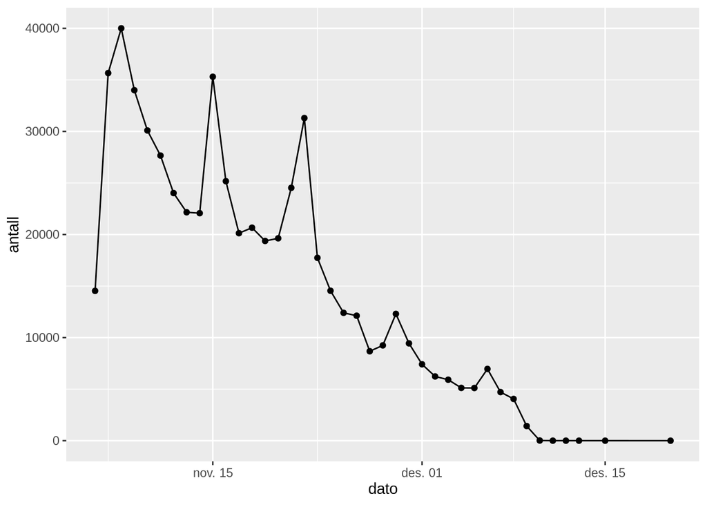

```r
ggplot(data.table(st)[, .(antall = .N), by =.(dato = as.POSIXct(format(st, "%Y-%m-%d"), format = "%Y-%m-%d"))], aes(dato, antall)) + geom_point() + geom_line()
```

Diagrammet viser at etter 6. november 2015 øker seertallene frem til første søndag. Deretter avtar de kraftig. De to påfølgende søndagene går seertallene i taket, men etter det er ikke seertallene like merkante på søndager.

Nå lager jeg en ny variabel som viser tidspunktet episoden var ferdig.

```r
vt = dt$visitStartTime + dt$timeWithinVisit/1000
vt = structure(vt, class=c('POSIXt', 'POSIXct'))
head(vt)
```

```
## [1] "2015-11-15 21:17:15 CET" "2015-11-15 10:36:41 CET"
## [3] "2015-11-10 19:45:29 CET" "2015-11-10 08:30:36 CET"
## [5] "2015-11-10 22:20:24 CET" "2015-11-10 12:28:54 CET"
```

Lager en variabel som viser tidsdelta i timer, minutter og sekunder fra sesjonen startet til episoden var ferdig.

```r
## Må trekke fra én time på grunn av tidssonen. Hvis jeg ikke gjør det blir datoen 1970-01-01 01:00:00 som blir forvirrende.
td = structure(vt - st - 3600, class=c('POSIXt', 'POSIXct'))
## td = format(td-3600, "%H:%M:%OS3")
head(td)
```

```
## [1] "1970-01-01 00:26:54 CET" "1970-01-01 00:29:42 CET"
## [3] "1970-01-01 00:03:26 CET" "1970-01-01 00:27:10 CET"
## [5] "1970-01-01 01:11:14 CET" "1970-01-01 00:40:39 CET"
```

Jeg undersøker igjen fordelingen på denne variabelen.

```r
format(quantile(td), "%H:%M:%OS3")
```

```
##             0%            25%            50%            75%           100%
## "00:00:00.000" "00:26:56.244" "00:39:47.917" "01:16:08.217" "09:03:08.460"
```

```r
format(mean(td), "%H:%M:%OS3")
```

```
## [1] "00:55:27.026"
```

Minste besøkstiden er null millisekunder. Denne typen observasjoner er kanskje bare støy som bør ryddes opp i, men jeg utsetter det. Største besøkstid er litt over ni timer.

Medianen er på litt under 40 minutter, mens gjennomsnittet er på 55,5 minutter. Siden lengden på episodene er like under 30 minutter, kan dette tyde på at mange har sett i alle fall én episode i løpet av besøkstiden, men det kan også være at brukeren har surfet på andre sider før vedkommende startet avspillingen. Verdien på første kvantil kan tyde på at det i alle fall er 25 % som ikke har sett episoden ferdig (eller spolt gjennom den). Hva er egentlig andelen som har en besøkstid på mindre enn 30 minutter?

```r
length(td[td<as.POSIXct("1970-01-01 00:30:00", format = "%Y-%m-%d %T")])/length(td)
```

```
## [1] 0.4078444
```

Svar: Nesten 41 %.

(Lurer på hvor mange episoder brukeren som hadde lengst besøkstid, så:

```r
dt[userId == userId[timeWithinVisit == max(timeWithinVisit)]][order(visitStartTime, timeWithinVisit)]
```

```
##                userId    programId visitStartTime timeWithinVisit
## 1: 608600487924476192 KMTE20000114     1446806596        25641920
## 2: 608600487924476192 KMTE20000214     1446806596        27377278
## 3: 608600487924476192 KMTE20000314     1446806596        29150708
## 4: 608600487924476192 KMTE20000414     1446806596        30887573
## 5: 608600487924476192 KMTE20000514     1446806596        32588460
## 6: 608600487924476192 KMTE20000614     1446863469         1880891
```

Det ser ut til at brukeren så de fem første episodene, men at vedkommende hadde begynt å se Unge lovende ganske sent i besøket.)

Legger til variablene til dt.

```r
dt[, c('episode', 'sesjonstart', 'episodeslutt', "delta") := .(ep, st, vt, td)]
head(dt)
```

```
##                 userId    programId visitStartTime timeWithinVisit episode
## 1: 2172883450372358834 KMTE20000514     1447617021         1614261       5
## 2: 2214426530139075244 KMTE20000314     1447578419         1782834       3
## 3: 3261020776373483236 KMTE20000114     1447180923          206935       1
## 4: 3300130967635711526 KMTE20000114     1447139006         1630400       1
## 5: 3303148955234989541 KMTE20000614     1447186150         4274932       6
## 6: 3328043191237614106 KMTE20000114     1447152495         2439821       1
##            sesjonstart        episodeslutt               delta
## 1: 2015-11-15 20:50:21 2015-11-15 21:17:15 1970-01-01 00:26:54
## 2: 2015-11-15 10:06:59 2015-11-15 10:36:41 1970-01-01 00:29:42
## 3: 2015-11-10 19:42:03 2015-11-10 19:45:29 1970-01-01 00:03:26
## 4: 2015-11-10 08:03:26 2015-11-10 08:30:36 1970-01-01 00:27:10
## 5: 2015-11-10 21:09:10 2015-11-10 22:20:24 1970-01-01 01:11:14
## 6: 2015-11-10 11:48:15 2015-11-10 12:28:54 1970-01-01 00:40:39
```

Hva kan vi nå lese fra dette? Jeg finner en bruker som har sett flere episoder.

```r
a = dt[, .(unikeEpisoder = uniqueN(episode)), by = .(userId, sesjonstart)]
head(a)
```

```
##                 userId         sesjonstart unikeEpisoder
## 1: 2172883450372358834 2015-11-15 20:50:21             2
## 2: 2214426530139075244 2015-11-15 10:06:59             4
## 3: 3261020776373483236 2015-11-10 19:42:03             5
## 4: 3300130967635711526 2015-11-10 08:03:26             1
## 5: 3303148955234989541 2015-11-10 21:09:10             2
## 6: 3328043191237614106 2015-11-10 11:48:15             1
```

Jeg velger brukeren på tredje linje og sorterer utskriften kronologisk.

```r
dt[userId == userId[3]][order(sesjonstart, episodeslutt)]
```

```
##                 userId    programId visitStartTime timeWithinVisit episode
## 1: 3261020776373483236 KMTE20000514     1447169969         1661148       5
## 2: 3261020776373483236 KMTE20000614     1447169969         3449311       6
## 3: 3261020776373483236 KMTE20000114     1447180923          206935       1
## 4: 3261020776373483236 KMTE20000214     1447180923         1838168       2
## 5: 3261020776373483236 KMTE20000314     1447180923         3582927       3
## 6: 3261020776373483236 KMTE20000414     1447180923         5347504       4
## 7: 3261020776373483236 KMTE20000514     1447180923         6440037       5
##            sesjonstart        episodeslutt               delta
## 1: 2015-11-10 16:39:29 2015-11-10 17:07:10 1970-01-01 00:27:41
## 2: 2015-11-10 16:39:29 2015-11-10 17:36:58 1970-01-01 00:57:29
## 3: 2015-11-10 19:42:03 2015-11-10 19:45:29 1970-01-01 00:03:26
## 4: 2015-11-10 19:42:03 2015-11-10 20:12:41 1970-01-01 00:30:38
## 5: 2015-11-10 19:42:03 2015-11-10 20:41:45 1970-01-01 00:59:42
## 6: 2015-11-10 19:42:03 2015-11-10 21:11:10 1970-01-01 01:29:07
## 7: 2015-11-10 19:42:03 2015-11-10 21:29:23 1970-01-01 01:47:20
```

Brukeren begynte å se episode fem 10. november 2015. Denne episoden var ferdig 27 minutter etter at sesjonen på NRK TV ble startet kl. 16:39. Deretter så brukeren episode seks som var ferdig en halv time senere. Neste sesjon startet 19:42 samme dag. Da så brukeren ferdig første episode 3 minutter(?) etter starten på sesjonen. De neste fire episodene gikk slag i slag, og brukeren avsluttet 1:47 timer etter sesjonsstart. Brukeren hadde vært innom episode fem to ganger.

La oss se på noen statistikker.

Jeg starter igjen med fordelingen av episoder per bruker.

```r
dt[, .(antallEpisoder = .N), keyby = userId][, c(quantile(antallEpisoder), snitt= mean(antallEpisoder))]
```

```
##         0%        25%        50%        75%       100%      snitt
##   1.000000   1.000000   4.000000   6.000000 240.000000   3.974854
```

Interessant, 240 episoder for én bruker. Jeg må snoke litt.

```r
u = dt[, .(antallEpisoder = .N), keyby = userId][userId == userId[antallEpisoder == 240]]$userId
dt[userId == u][order(sesjonstart, episodeslutt)][1:50]
```

```
##                 userId    programId visitStartTime timeWithinVisit episode
##  1: 325201099589514985 KMTE20000114     1446981893         3332118       1
##  2: 325201099589514985 KMTE20000214     1446981893         5081931       2
##  3: 325201099589514985 KMTE20000314     1446981893         6843783       3
##  4: 325201099589514985 KMTE20000414     1446981893         9274770       4
##  5: 325201099589514985 KMTE20000514     1446981893        11007521       5
##  6: 325201099589514985 KMTE20000614     1446981893        13421626       6
##  7: 325201099589514985 KMTE20000114     1446981893        14882509       1
##  8: 325201099589514985 KMTE20000214     1446981893        15444809       2
##  9: 325201099589514985 KMTE20000314     1446981893        16031854       3
## 10: 325201099589514985 KMTE20000414     1446981893        16674031       4
## 11: 325201099589514985 KMTE20000514     1446981893        17791506       5
## 12: 325201099589514985 KMTE20000614     1447002451          675521       6
## 13: 325201099589514985 KMTE20000114     1447006658          992408       1
## 14: 325201099589514985 KMTE20000514     1447006658         1943474       5
```

[output cut: 89 more lines]

Her var det mye rart. Jeg lar det ligge.

Hvor mange har vært innom de ulike episodene?

```r
(p = dt[, .(antallBrukere = uniqueN(userId)), by = episode][order(episode)])
```

```
##    episode antallBrukere
## 1:       1        111858
## 2:       2         95394
## 3:       3         90706
## 4:       4         89433
## 5:       5         88099
## 6:       6         87540
```

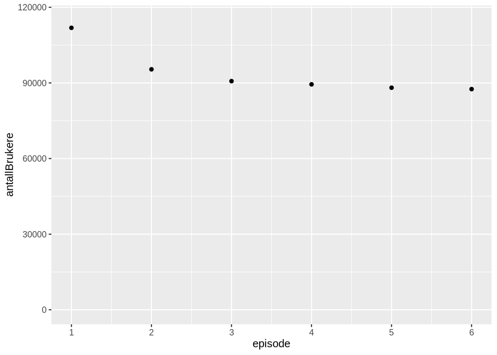

```r
ggplot(p, aes(episode, antallBrukere)) + geom_point() + scale_x_continuous(breaks=c(1,2,3,4,5,6), labels=c(1,2,3,4,5,6)) + coord_cartesian(ylim= c(0,115000))
```

Nesten 112 000 har sett episode 1. Dette tallet synker til ca. 95 000 for episode 2 og siden minker det til ca. 87 500. Jeg syns det er litt rart at av 148 000 brukere har bare 112 000 sett episode 1.

Ut fra NRKs perspektiv, tror jeg det ville være interessant å få besvart følgende spørsmål:

1. Hvor mange har sett alle episodene?
2. Når ble de ulike episodene sett?
3. Hvor mange så serien idet den ble sluppet?
4. Hvor mange har bare sett noen episoder?
5. Hvor mange har bare sett en ufullstendig episode?
6. Hva er alderen på seerne?

De tre første spørsmålene sier noe om dem som likte serien, mens de to neste spørsmålene sier noe om hvor mange som ikke likte den så godt. Det siste sier noe om hvilken aldersgruppe man treffer med serien, men dette gir ikke datasettet svar på.

La oss se når episodene ble sett

```r
tp = dt[, .(Antall=.N), by = .(dato = format(episodeslutt, "%Y-%m-%d"), tid = format(episodeslutt, "%H"))]
tp[, c("dato", "tid") := .(as.POSIXct(dato, format = "%Y-%m-%d"), as.POSIXct(tid, format = "%H"))]
head(tp)
```

```
##          dato                 tid Antall
## 1: 2015-11-15 2019-11-27 21:00:00   3096
## 2: 2015-11-15 2019-11-27 10:00:00   1019
## 3: 2015-11-10 2019-11-27 19:00:00   1965
## 4: 2015-11-10 2019-11-27 08:00:00    328
## 5: 2015-11-10 2019-11-27 22:00:00   3562
## 6: 2015-11-10 2019-11-27 12:00:00    840
```

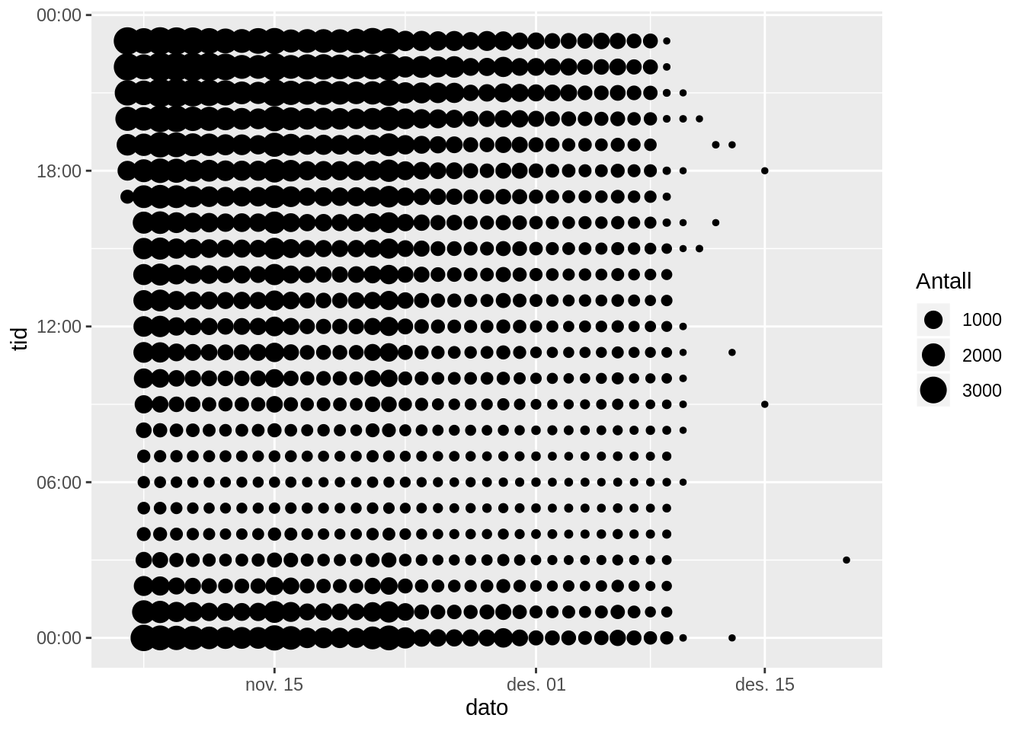

```r
ggplot(tp, aes(dato, tid, size=Antall)) + geom_point() + scale_y_datetime(date_labels = "%R")
```

Dette ikke så informativt som jeg hadde håpet. Seerantall per dag har vi allerede sett på lengre oppe.

La oss finne ut hvor mange som har sett alle episodene.

```r
ae = dt[,.(settEpisoder = uniqueN(episode)) ,by = .(userId)]
head(ae)
```

```
##                 userId settEpisoder
## 1: 2172883450372358834            2
## 2: 2214426530139075244            4
## 3: 3261020776373483236            6
## 4: 3300130967635711526            1
## 5: 3303148955234989541            6
## 6: 3328043191237614106            6
```

```r
ae[, .(antall = .N), by = settEpisoder][order(-settEpisoder)]
```

```
##    settEpisoder antall
## 1:            6  58102
## 2:            5  13290
## 3:            4  10407
## 4:            3  11135
## 5:            2  17494
## 6:            1  37947
```

```r
ae[, .N]  ## Sjekker at dette summerer seg til antall unike brukere
```

```
## [1] 148375
```

Ca. 58 000 har sett alle episodene. Nesten 38 000 har bare sett én episode. Litt over 52 000 har sett mellom to og fem episoder.

## Seriefråtsing (Binge-watching)

Definisjonen på seriefråtsing er litt vag, men i henhold til wikipedia viste en undersøkelse som Netflix gjorde i februar 2014 at 73 % definerer seriefråtsing som å se mellom to og seks episoder i strekk. Wikipedia henviser også til en artikkel av Trouleau, Ashkan, Ding og Eiksson (2016)[^1] som argumenterer med at definisjonen bør sees i konteksten av innholdet i programmet.

Hvor mange har sett mer enn én episode i strekk?

Hvordan kan “i strekk” defineres på bakgrunn av tilgjengelige data? Jeg kan tenke meg tre forslag til definisjon:

1. Brukere som har flere episoder med samme sesjonstart.
2. Punkt 1 i tillegg til at episodene er i koronoloisk rekkefølge.
3. Det er minder enn 30 min differanse i besøkstid mellom to episoder.

I punkt én blir det ikke tatt hensyn til om det er en lengre pause mellom to episoder, eller hvor vidt episodene følger hverandre kronologisk. (Jeg har ikke sett Unge lovende, men jeg har inntrykk av at episodene følger en kronologisk utvikling og dermed ikke er ment å bli sett uavhengig.)

Punkt to setter krav om at episodene skal bli sett i kronologisk rekkefølge. Dette er egentlig ikke et krav for seriefråtsing. Definisjonen gjør ikke noe med krav om pause.

Punkt tre settes det krav om at episodene følger hverandre med mindre enn 30 min mellom hver episode. Jeg tror det er sannsynlig at episodene også følger kronologisk ut fra dette kravet. Dermed vil punkt tre være inneholdt i punkt to som vil være inneholdt i punkt én.

Etter å ha tenkt litt, er inntrykket mitt at punkt tre er den definisjonen som er nærmest å fange opp seriefråtsning av dem jeg har foreslått. La meg allikevel se litt bredt på det ved å telle opp antallet i definisjon én.

Jeg teller opp hvor mange brukere som har sett flere episoder med samme starttid. For å få til dette må jeg finne starttiden for den første episoden som ble sett for hver unike kombinasjon av bruker og starttid.

```r
dt[, rank:=frank(episodeslutt), by=.(userId, sesjonstart)]
dt[(userId == userId[rank == max(rank)]) & (sesjonstart == sesjonstart[rank == max(rank)])][order(sesjonstart, episodeslutt)]
```

```
##                  userId    programId visitStartTime timeWithinVisit episode
##  1: 5625889031477347600 KMTE20000514     1447285656         1015868       5
##  2: 5625889031477347600 KMTE20000614     1447285656         2169841       6
##  3: 5625889031477347600 KMTE20000514     1447285656         3355788       5
##  4: 5625889031477347600 KMTE20000414     1447285656         3802744       4
##  5: 5625889031477347600 KMTE20000314     1447285656         4212693       3
##  6: 5625889031477347600 KMTE20000114     1447285656         6215782       1
##  7: 5625889031477347600 KMTE20000214     1447285656         7986638       2
##  8: 5625889031477347600 KMTE20000314     1447285656         9821872       3
##  9: 5625889031477347600 KMTE20000414     1447285656        11841589       4
## 10: 5625889031477347600 KMTE20000514     1447285656        13615582       5
## 11: 5625889031477347600 KMTE20000614     1447285656        16342462       6
## 12: 5625889031477347600 KMTE20000114     1447285656        18103415       1
## 13: 5625889031477347600 KMTE20000214     1447285656        20802394       2
## 14: 5625889031477347600 KMTE20000314     1447285656        22577308       3
##             sesjonstart        episodeslutt               delta rank
##  1: 2015-11-12 00:47:36 2015-11-12 01:04:31 1970-01-01 00:16:55    1
##  2: 2015-11-12 00:47:36 2015-11-12 01:23:45 1970-01-01 00:36:09    2
##  3: 2015-11-12 00:47:36 2015-11-12 01:43:31 1970-01-01 00:55:55    3
##  4: 2015-11-12 00:47:36 2015-11-12 01:50:58 1970-01-01 01:03:22    4
##  5: 2015-11-12 00:47:36 2015-11-12 01:57:48 1970-01-01 01:10:12    5
##  6: 2015-11-12 00:47:36 2015-11-12 02:31:11 1970-01-01 01:43:35    6
##  7: 2015-11-12 00:47:36 2015-11-12 03:00:42 1970-01-01 02:13:06    7
##  8: 2015-11-12 00:47:36 2015-11-12 03:31:17 1970-01-01 02:43:41    8
##  9: 2015-11-12 00:47:36 2015-11-12 04:04:57 1970-01-01 03:17:21    9
## 10: 2015-11-12 00:47:36 2015-11-12 04:34:31 1970-01-01 03:46:55   10
## 11: 2015-11-12 00:47:36 2015-11-12 05:19:58 1970-01-01 04:32:22   11
## 12: 2015-11-12 00:47:36 2015-11-12 05:49:19 1970-01-01 05:01:43   12
## 13: 2015-11-12 00:47:36 2015-11-12 06:34:18 1970-01-01 05:46:42   13
## 14: 2015-11-12 00:47:36 2015-11-12 07:03:53 1970-01-01 06:16:17   14
```

Her har vi funnet en superseriefråtser!

Da er det bare å telle hva som er maks rank for hver gruppe.

```r
dt[, .(maksRank = max(rank)), by = .(userId, sesjonstart)][, .(.N), by = .(maksRank)][order(maksRank)]
```

```
##     maksRank      N
##  1:        1 158716
##  2:        2  71413
##  3:        3  32363
##  4:        4  17784
##  5:        5   9817
##  6:        6  11198
##  7:        7    332
##  8:        8     70
##  9:        9     16
## 10:       10     30
## 11:       11     10
## 12:       12     22
## 13:       13      1
## 14:       14      1
```

```r
dt[, .(maksRank = max(rank)), by = .(userId, sesjonstart)][, c(quantile(maksRank), snitt = mean(maksRank))]
```

```
##        0%       25%       50%       75%      100%     snitt
##  1.000000  1.000000  1.000000  2.000000 14.000000  1.954346
```

Det er visst noen som ser serien flere ganger i strekk. Over halvparten ser i alle fall kun én episode av Unge lovende per besøk.

Nå legger jeg til en variabel som forteller hvor mange minutter det er mellom slutten av to etterfølgende episoder.

```r
df = dt[order(userId, sesjonstart, episodeslutt), .(deltaForrige = difftime(episodeslutt, shift(episodeslutt, 1, type="lag"), units = "mins")), keyby = .(userId, sesjonstart)]
```

I tillegg er jeg interessert i å se spredningen i tidsforskjellen mellom slutttidene til episodene.

```r
df[, c(quantile(deltaForrige, na.rm=TRUE), snitt =  mean(deltaForrige, na.rm=TRUE))]
```

```
## Time differences in mins
##           0%          25%          50%          75%         100%        snitt
## 1.666546e-05 2.893457e+01 2.963405e+01 3.215149e+01 2.502408e+02 3.079003e+01
```

Mellom første og tredje kvartil ligger 28,9 til 32,2 minutter. Jeg tenker at dette er OK tidsintervaller mellom påfølgende episoder for at det skal kalles seriefråtsing.

Hvor mange har sett to, tre, osv episoder med mindre enn 35 minutter mellom sluttidene?

```r
df[deltaForrige < 35, .(påfølgendeEpisoder = .N), by = .(userId, sesjonstart)][, .(antall = .N), by = .(påfølgendeEpisoder)][order(påfølgendeEpisoder)]
```

```
##     påfølgendeEpisoder antall
##  1:                  1  68917
##  2:                  2  29293
##  3:                  3  15157
##  4:                  4   9131
##  5:                  5   6065
##  6:                  6    195
##  7:                  7     44
##  8:                  8     25
##  9:                  9     18
## 10:                 10     15
## 11:                 11     11
```

Utskriften viser at det er 68 917 brukere som har hatt en sesjon hvor de har sett to episoder etter hverandre.

Jeg avslutter her. Definisjonen jeg bruker på seriefråtsing her kan ennå jobbes mer med. For eksempel viser utskriften over at 25 % av påfølgene episoder starter mindre enn 28,9 minutter etter forrige sluttet. Disse episodene har ikke blitt sett i sin helhet under samme sesjon (hvis de da ikke blir gjenopptatt senere i sesjonen.)

Uansett, dette var gøy. Håper jeg får jobben!

[^1]: https://dl.acm.org/citation.cfm?doid=2939672.2939792